# Data Exploration Project

Glen Lewis

2/18/2021

The U.S. Department of Education published the first College Score Card in 2015. This score card included the once hard to find metric: post-graduation earning, the earnings alumni reported 10 years after graduation (‘earnings’ for this analysis). The following examines if schools’ whose graduates earned more received more interest from perspective students following publication of the first score card.

H<sub>0</sub> = College Score Card publication had no impact on perspective student interest in High Earning Schools

H<sub>a</sub> = Publication of the College Score Card increased interest in High Earning Schools

## Defining High and Low ‘Earning’ Schools

The first challenge is defining low and high earning institutions. Initial visualization and descriptive statistics show reported graduate earnings interquartile range being -.159 to .786 standard deviations (std) from the mean earnings. For the purposes of this analysis, therefore, we define high earning schools as those whose graduates reported earnings above the 75th percentile (.786) and conversely, we defined low earning schools as those schools whose graduates reported below the 25th percentile (-.159).

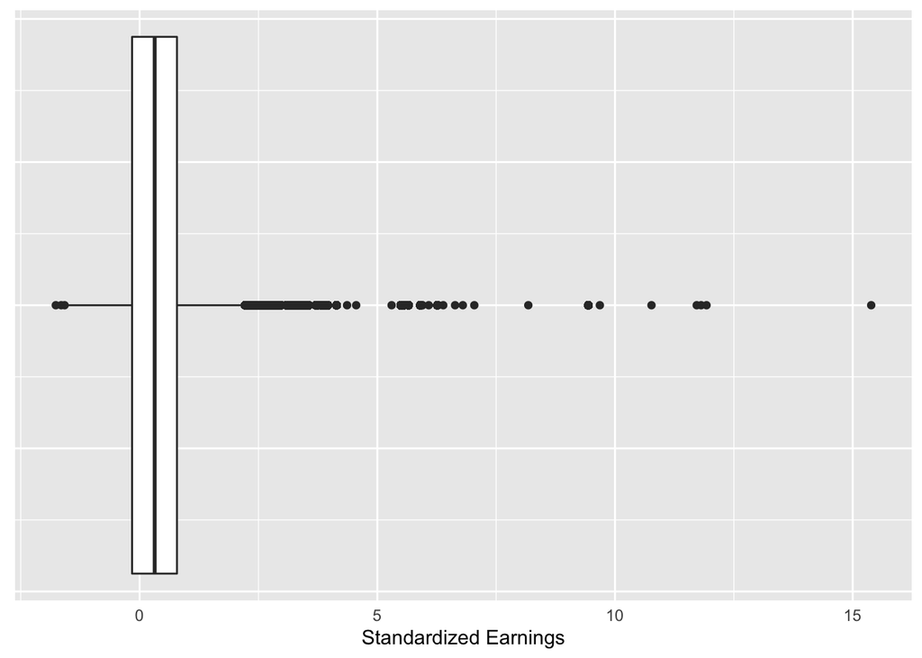

## Did Graduate Reported Earnings Influence Index Scores Prior to 2015?

While the visualizations for schools with high earnings did not show a clear relationship prior to 2015, the regression models did show an identifiable relationship between higher earnings and school index score.

If higher earnings drove interest toward a particular school (as represented by the index score) you would expect higher earning schools to have average index score consistently above the overall average index score for all schools. While some high earning schools’ index scores are consistently above the average there are also several that have average or below average index scores.

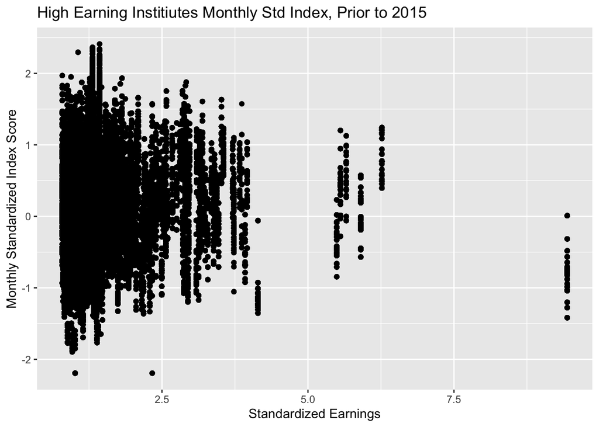

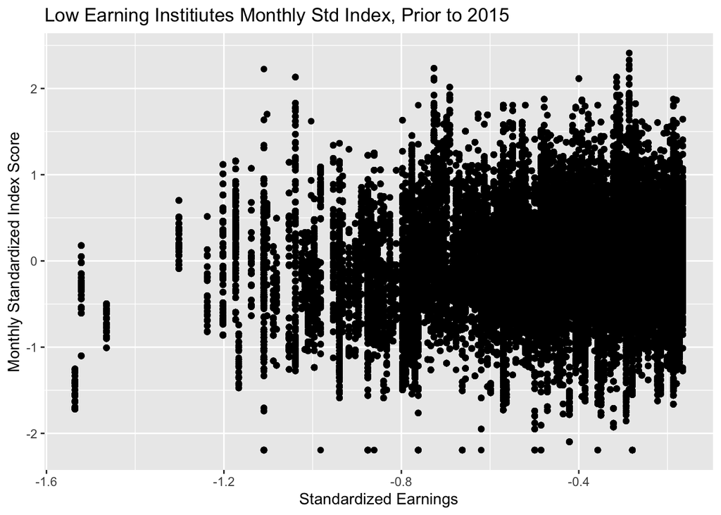

Two different regression models where examined:

1. a “straight” model of monthly average standardized index score against the standardized earning for each school for 2013 and 2014.
2. a “polynomial” model of the same variables. The polynomial was intended to address the outliers.
3. a “month” control variable was added since interest in schools is seasonal, i.e., interest increases and wanes in the spring and summer as students begin the application process for their first fall classes.

The “straight” regression model (st_pre_2015_hi_lm) supported the notion that earnings had only a small influence on index scores prior to 2015; with a one 1 std increase in earnings causing a .01 increase in index score. For model fit: the effects plot shows the B<sub>1</sub> coefficient nicely including index scores out to 5.0 std. It is suspected; however, that the low index scores for schools above 7.5 std earnings is artificial dragging down that coefficient for schools with earnings below 5 std.

The “polynomial” regression model (poly_pre_2015_hi_lm) offered better insight into how increases in earnings affected index score. The model showed that for very 1 std increase in standardized earnings there was a .18 increase in index score until approximately 3 std (B<sub>1</sub>/(2B<sub>2</sub>), ~$75500) when the index score decreased by .03 for each 1 std increase in earnings. This makes sense as some these higher earning schools could be specialty schools that draw the attention of a small segment of the overall prospective student population. Drawing the attention of a smaller pool of students would lead to lower index scores when compared to the whole.

|  | pre_2015_hi_lm | poly_pre_2015_hi_lm | pre_2015_low_lm |
| --- | --- | --- | --- |
| (Intercept) | 0.29 *** | 0.12 *** | 0.28 *** |
|  | (0.00) | (0.01) | (0.00) |
| sd_earnings | 0.01 *** | 0.18 *** | 0.18 *** |
|  | (0.00) | (0.00) | (0.01) |
| month | -0.01 *** | -0.01 *** | -0.03 *** |
|  | (0.00) | (0.00) | (0.00) |
| I(sd_earnings^2) |  | -0.03 *** |  |
|  |  | (0.00) |  |
| N | 223852 | 223852 | 222186 |
| R2 | 0.01 | 0.01 | 0.03 |
| *** p < 0.001; ** p < 0.01; * p < 0.05. |  |  |  |

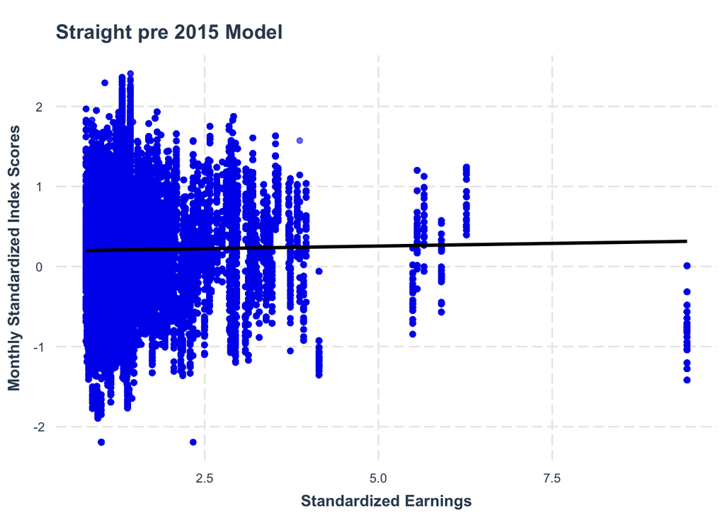

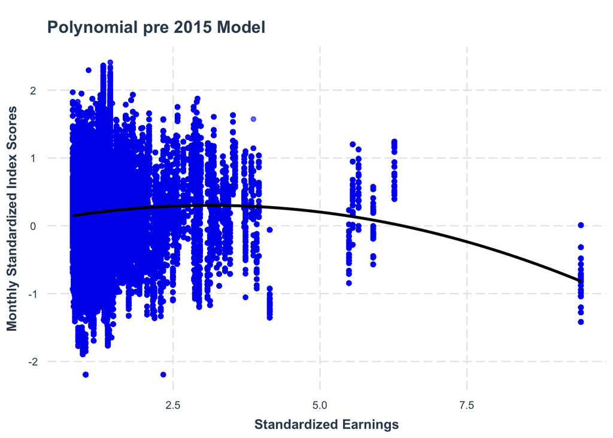

# Index Scores After to 2015

The visualizations of post 2015 data, appears to show an interesting change on the potential relationship between higher earnings schools and their index score. In the “High Earning Institute Std Index Post 2015” there is a noticeable negative shift in standardized index scores for all schools. Additionally, the variation in index scores for schools above 5 std in earnings (~$104000) remained consistent with pre 2015 scores indicating more even year-round interest in those schools. Those scores; however, remained mostly +/- 1 std of the overall average score. Again, there is no significant difference in the high earning schools’ average index score from that of the overall average score.

The polynomial model supports this. Both models’ intercepts are considerably lower than the pre 2015 models while there is no change in the post 2015 B<sub>1</sub>, B<sub>2</sub> coefficients.

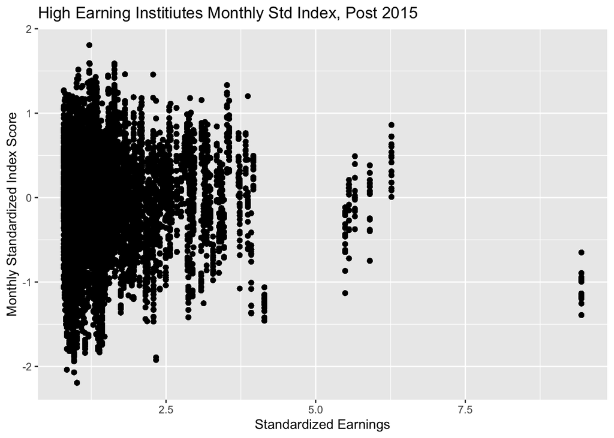

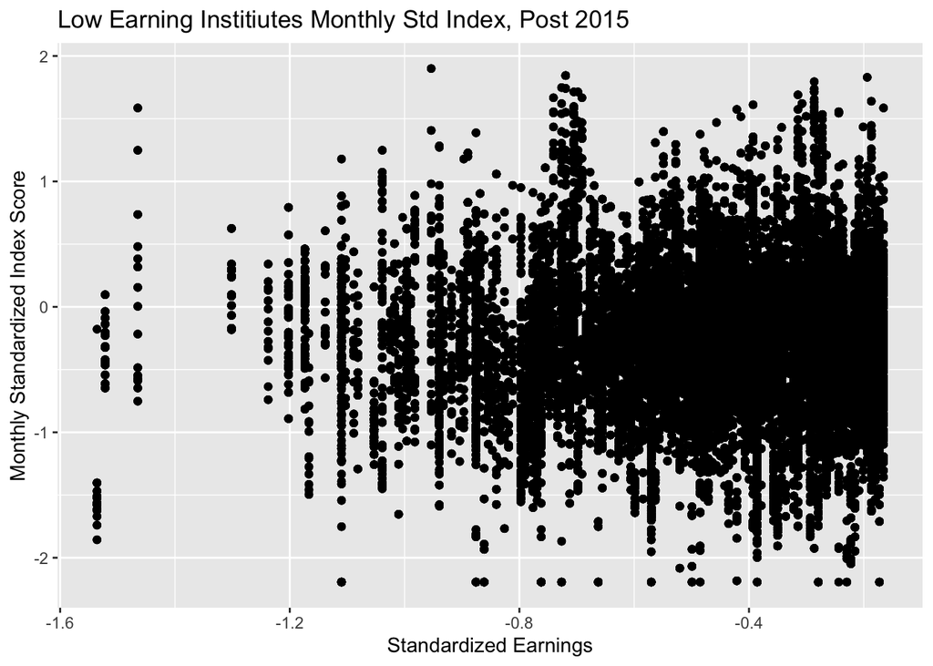

|  | poly_post_2015_hi_lm | post_2015_low_lm |
| --- | --- | --- |
| (Intercept) | -0.20 *** | -0.15 *** |
|  | (0.01) | (0.00) |
| sd_earnings | 0.18 *** | 0.08 *** |
|  | (0.00) | (0.01) |
| I(sd_earnings^2) | -0.03 *** |  |
|  | (0.00) |  |
| month | -0.01 *** | -0.01 *** |
|  | (0.00) | (0.00) |
| N | 156941 | 156086 |
| R2 | 0.01 | 0.01 |
| *** p < 0.001; ** p < 0.01; * p < 0.05. |  |  |

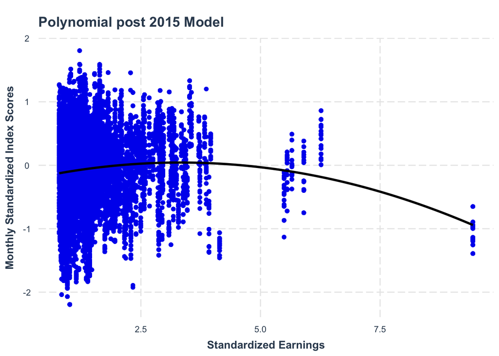

The post 2015 low earning school model also had a significant change in its coefficient, showing that index score increased by only .08 for every increase in standardized earnings verses the pre 2015 coefficient of .18.

Of interest the month control variable coefficient showed -.01, indicating that for every month that passed there was a .01 decrease in standardized index score. This is not surprising as the year progress toward the beginning of the fall college season, interest would wane as prospective student settle on schools over the summer.

|  | poly_post_2015_hi_lm | post_2015_low_lm |
| --- | --- | --- |
| (Intercept) | -0.20 *** | -0.15 *** |
|  | (0.01) | (0.00) |
| sd_earnings | 0.18 *** | 0.08 *** |
|  | (0.00) | (0.01) |
| I(sd_earnings^2) | -0.03 *** |  |
|  | (0.00) |  |
| month | -0.01 *** | -0.01 *** |
|  | (0.00) | (0.00) |
| N | 156941 | 156086 |
| R2 | 0.01 | 0.01 |
| *** p < 0.001; ** p < 0.01; * p < 0.05. |  |  |

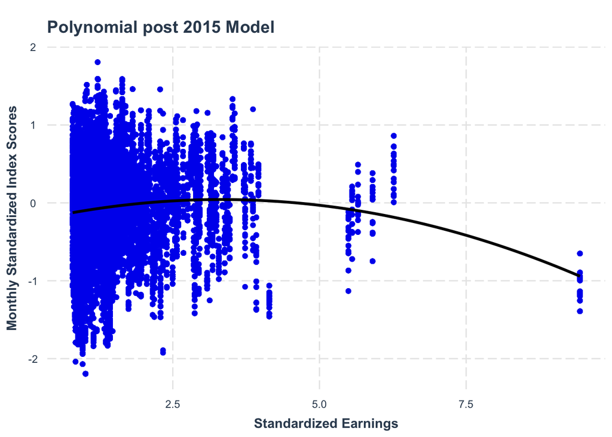

# Conclusion

The data above indicates that publication of the College Score Card and its report on graduate earnings did not have an influence on the college index scores.

There was a noticeable negative shift in index scores indicating a reduced overall interest in the reported schools following 2015. That shift could be the result of other effects outside of the publication of the College Score Card such as the increased enrollment in vocational schools that teach skills that once required four year degrees.